# **Sentiment Analysis NLP Project! 📊😄😡**

##### Validation Accuracy ~ 57.11%

##### Test Accuracy ~ 56.41%.

```python
# now im going to adjust the learning rate just out of curiosity ... lets see if there are any effects there ...
```

```python
model.compile(optimizer=Adam(learning_rate=0.0003), loss='binary_crossentropy', metrics=['accuracy'])
history = model.fit(
    X_train, y_train,
    validation_data=(X_val, y_val),
    epochs=15,
    batch_size=32,
    callbacks=[early_stopping],
    verbose=1
)

early_stopping = EarlyStopping(monitor='val_loss', patience=7, restore_best_weights=True)
```

```
WARNING:absl:At this time, the v2.11+ optimizer `tf.keras.optimizers.Adam` runs slowly on M1/M2 Macs, please use the legacy Keras optimizer instead, located at `tf.keras.optimizers.legacy.Adam`.
WARNING:absl:There is a known slowdown when using v2.11+ Keras optimizers on M1/M2 Macs. Falling back to the legacy Keras optimizer, i.e., `tf.keras.optimizers.legacy.Adam`.
```

```
Test Loss: 0.6743
Test Accuracy: 0.5648
```

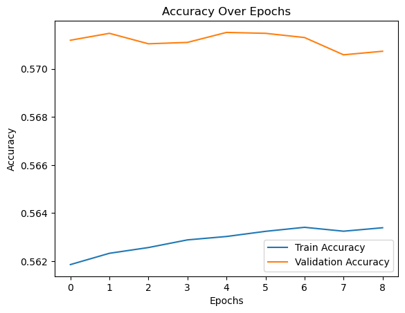

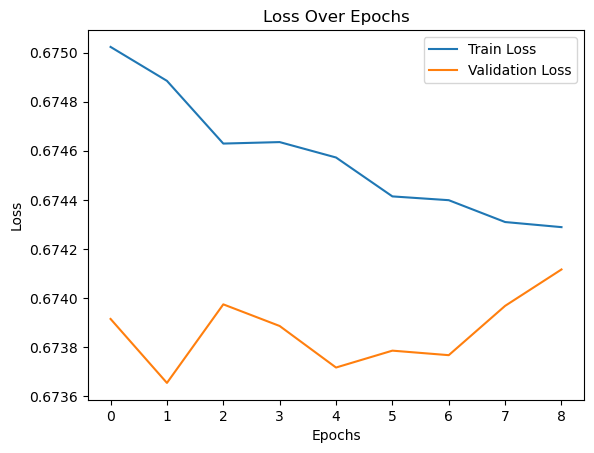

```python
# re evaluating on the test set using same code ....
loss, accuracy = model.evaluate(X_test, y_test, verbose=0)
print(f"Test Loss: {loss:.4f}")
print(f"Test Accuracy: {accuracy:.4f}")

# visuals for our updated accuracy and loss
plt.plot(history.history['accuracy'], label='Train Accuracy')
plt.plot(history.history['val_accuracy'], label='Validation Accuracy')
plt.title('Accuracy Over Epochs')
plt.xlabel('Epochs')
plt.ylabel('Accuracy')
plt.legend()
plt.show()

plt.plot(history.history['loss'], label='Train Loss')
plt.plot(history.history['val_loss'], label='Validation Loss')
plt.title('Loss Over Epochs')
plt.xlabel('Epochs')
plt.ylabel('Loss')
plt.legend()
plt.show()
```

Our above experiment 3, in where I further adjusted learning rate. We can see that it shows a marginal improvement compared to previous runs! Good sign.

### Last few observations:

##### Test Accuracy: Slightly increased to 56.48%, up from 56.41% in step 2.

##### Validation Accuracy: Peaked at 57.15%, matching the best observed so far!!

### Loss Behavior:

##### I will annote that slight oscillation in validation loss during the later epochs does suggests to us that our model is approaching its performance ceiling with the current architecture and data! We will have to continue fine-tuning our studies.